# Listen to the Tapes - Einstein's Assistant and Einstein at Roswell just after the crash

Who is in charge of all this hiding and lying? That was my first reaction. My second is: the gall of these bastards! We could have been a clean energy-secure species, have made incredible discoveries, helped heal the planet, and experienced the opportunity to vastly expand our own development instead of F’ing over each other like greedy crabs in a basket. Aren’t we sick of this behavior of ours yet? What you’re going to hear hurts. It may make you angry.

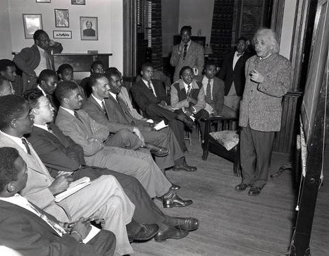

Einstein at Lincoln University, PA

I’ve been given permission to link to these tapes by Anthony Braglia, a long-time UFO researcher. The tapes are an interview conducted by a former MUFON researcher named Sheila Franklin back in 1993. She spoke with Einstein’s ‘pet’ favorite assistant and student at the time, a woman named Shirley Wright who earned two PhDs in Physical Chemistry and Physical Science and became a professor of chemistry. She taught at the University of Miami, Barry College, Hialeah High School, and MDCC. She went to Roswell just after the crash and retrieval with Einstein. It was a US government request that sent them there. **Officially it never happened but it did, and you can [hear](https://www.ufoexplorations.com/einsteins-secret-trip-to-view-roswell-ufo) for yourself.** Officially, there’s a lot that never happens like seeing orbs and drones zig-zagging across the sky or rising out of the ocean, missing time, ships dashing into volcanoes - retrievals, reverse engineering anyone? Yet, we’ve been kept in the dark for a long time. By whom is the real question? And why?

Shirley’s responses are absolutely remarkable, descriptive, normal in tone and void of any hype or self-aggrandizement. She plainly steps through the questions posed by Sheila where one can hear in her voice what sounds like an honest retelling of the Roswell events that she and Einstein were part of. Recalling the real events, Shirley recounts that one of the beings had survived and was communicating telepathically to the humans. Firsthand, she describes their physicality clothed and from hearsay, unclothed, their damaged ship, and the activities of the humans inside the secret military facility in the south-western US. There were 9 of these beings, and at the time of Einstein’s and Shirley’s visit only one being was still alive. As relayed or implied by the surviving alien, that she describes with grayish-green skin and of a different form than the others, is partly the message that we definitely aren’t apex creatures in this universe. It seems that our capacities are so nascent and limited that we are not a threat. This inference or revelation is very similar to Lacerta’s views on humans from the [Lacerta Files](https://www.bibliotecapleyades.net/vida_alien/esp_vida_alien_52.htm). We’re like babies just able to stand upright. One step to walking with balance is full disclosure. We need to press hard for that. After that, the stars are limitless but we must go in peace and cooperation. Our Jungian shadow side needs to be understood and kept in check to advance and assume our place amongst the others. That’s our real challenge. It’s not the science, it’s to love one another.

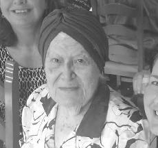

Dr. Shirley Wright

She’s not with us any longer. Here’s [her obituary](https://www.legacy.com/us/obituaries/herald/name/shirley-wright-obituary?pid=175222357). Here’s the link to the [taped interview.](https://www.ufoexplorations.com/einsteins-secret-trip-to-view-roswell-ufo)

**Hats off to Mr. Braglia.**

They’ll be more on this coming very soon I hope. Until then, again and as always:

> If what you’re going to do today doesn’t serve the love of the planet or the love of humanity - Don’t Do It! *Stephen*